# Project Foundations for Data Science: FoodHub Data Analysis

### Exploration of Ratings:

```python
# creates a numberic verison of ratings column for numerical analysis
df['rating_num'] = pd.to_numeric(df['rating'].replace('Not given', '0'))
df['rating_num'].head
```

```
<bound method NDFrame.head of 0       0
1       0
2       5
3       3
4       4
       ..
1893    5
1894    5
1895    0
1896    5
1897    0
Name: rating_num, Length: 1898, dtype: int64>
```

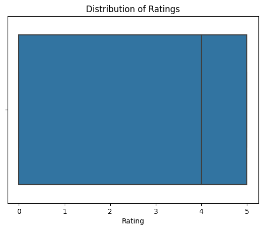

```python
#plotting a box plot of ratings
sns.boxplot(data=df, x='rating_num')
plt.title("Distribution of Ratings")
plt.xlabel('Rating');
```

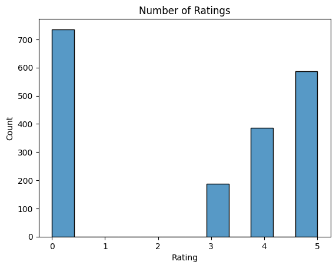

```python
# plotting a histogram of ratings
sns.histplot(data=df, x='rating_num')
plt.title('Number of Ratings')
plt.xlabel('Rating');
```

```python
# finds the percentage of each review level
ratings_percents = df.rating_num.value_counts(normalize=True).round(2)*100
ratings_percents
```

```
0    39.0
5    31.0
4    20.0
3    10.0
Name: rating_num, dtype: float64
```

### Exploration of Prep Time:

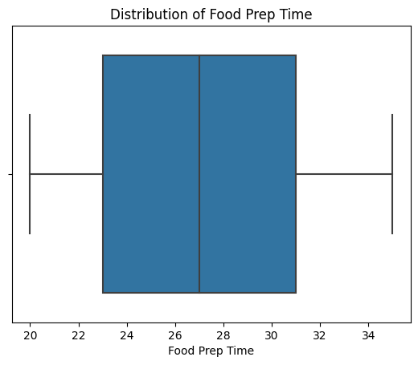

```python
# plotting box plot of food prep time
sns.boxplot(data=df, x='food_preparation_time')
plt.title("Distribution of Food Prep Time")
plt.xlabel('Food Prep Time');
```

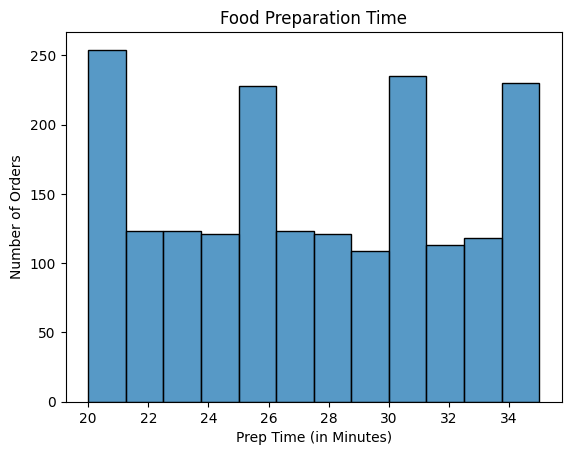

```python
# plotting histogram of food prep time
sns.histplot(data=df, x='food_preparation_time')
plt.title('Food Preparation Time')
plt.xlabel('Prep Time (in Minutes)')
plt.ylabel('Number of Orders');
```

#### Observations:

By looking at the box plot we can extract that the median food prep time for all orders was 27 minutes. The longest food prep time was 35 minutes, and the fastest was only 20 minutes. The middle 50 percent of orders were prepared between 23 and 31 minutes. What we are missing and can see through the histogram is that the most frequent prep time is actually the fastest, 20 minutes.

### Exploration of Delivery Time

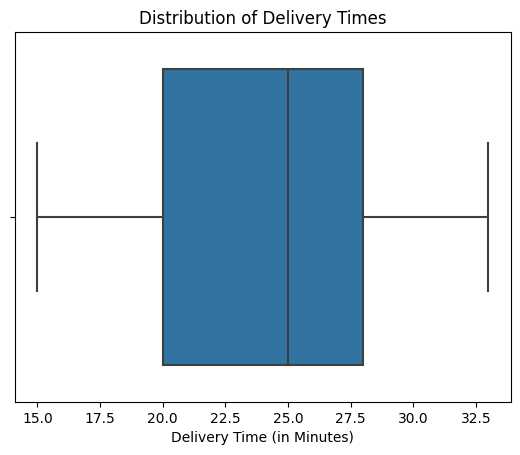

```python
#plotting boxplot of delivery times
sns.boxplot(data=df, x='delivery_time')
plt.title('Distribution of Delivery Times')
plt.xlabel('Delivery Time (in Minutes)');
```

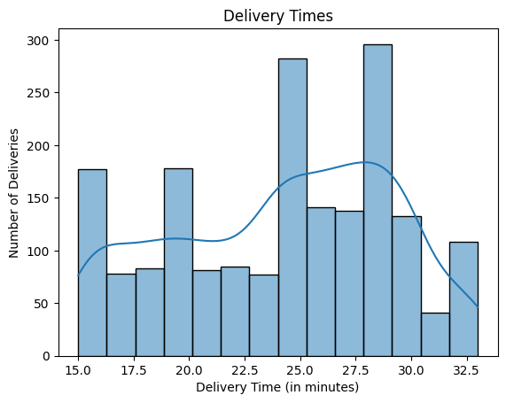

```python
#plotting histogram of delivery time
sns.histplot(data=df, x='delivery_time', kde=True)
plt.title('Delivery Times')
plt.xlabel('Delivery Time (in minutes)')
plt.ylabel('Number of Deliveries');
```

#### Observations of Delivery Time:

The median delivery time was about 25 minutes, with the middle 50% of deliveries taking between 20 and 28 minutes.

### **Question 7**: Which are the top 5 restaurants in terms of the number of orders received?

```python
# stores a series of top 5 restaurants in variable top_5 and displays it
top_5 = df.restaurant_name.value_counts().iloc[:5]

top_5
```

```
Shake Shack                  219
The Meatball Shop            132
Blue Ribbon Sushi            119
Blue Ribbon Fried Chicken     96
Parm                          68
Name: restaurant_name, dtype: int64
```

#### Observations

Listed above in descending order are the top 5 restaurants in terms of orders received.

### **Question 8**: Which is the most popular cuisine on weekends?

```python
# using groupby function to split cuisine type counts between weekday and weekend
df.groupby(df['day_of_the_week']).cuisine_type.value_counts()
```

```
day_of_the_week  cuisine_type
Weekday          American          169
                 Japanese          135
                 Italian            91
                 Chinese            52
                 Indian             24
                 Mexican            24
                 Middle Eastern     17
                 Mediterranean      14
                 Southern            6
                 French              5
                 Thai                4
                 Vietnamese          3
                 Korean              2
                 Spanish             1
Weekend          American          415
                 Japanese          335
                 Italian           207
                 Chinese           163
                 Mexican            53
                 Indian             49
                 Mediterranean      32
                 Middle Eastern     32
                 Thai               15
                 French             13
                 Korean             11
                 Southern           11
                 Spanish            11
                 Vietnamese          4
Name: cuisine_type, dtype: int64
```

#### Observations:

The most popular cuisine on the weekend is American.

### **Question 9**: What percentage of the orders cost more than 20 dollars?

```python
# create dataframe containing just orders over $20
df_cost_over_20 = df[df['cost_of_the_order'] > 20].copy()

#calculate the percentage of orders over 20
perc_over_20 = (df_cost_over_20.shape[0]/df.shape[0])*100

#print percentage
print('The percentage of orders that cost over $20 is: ',round(perc_over_20,2),'%.', sep='')
```

```
The percentage of orders that cost over $20 is: 29.24%.
```

#### Observations:

29.24% of orders cost more than $20.

### **Question 10**: What is the mean order delivery time?

```python
# finding the mean delivery time
df['delivery_time'].mean().round(2)
```

```
24.16
```

#### Observations:

The mean delivery time is 24.16 minutes.

### **Question 11:** The company has decided to give 20% discount vouchers to the top 3 most frequent customers. Find the IDs of these customers and the number of orders they placed

```python
# extracting the number of times each customer id appears as a value
num_orders = df.customer_id.value_counts()
num_orders.head()
```

```
52832     13
47440     10
83287      9
250494     8
259341     7
Name: customer_id, dtype: int64
```

```python
# displaying the top 3 customer ID Numbers based on number of orders
num_orders[:3]
```

```
52832    13
47440    10
83287     9
Name: customer_id, dtype: int64
```

#### Observations:

Customer numbers 52832, 47440 and 83287 should recieve vouchers.

### **Question 12**: Perform a multivariate analysis to explore relationships between the important variables in the dataset. (It is a good idea to explore relations between numerical variables as well as relations between numerical and categorical variables)

#### Ratings by Cuisine Type

```python
# creating additonal dataframe with the average ratings by cuisine type
df_rated = df[df['rating'] != 'Not given'].copy()
df_cuisine_ratings = df_rated.groupby('cuisine_type', as_index=False)['rating_num'].mean()
df_cuisine_ratings
```

|  | cuisine_type | rating_num |
| --- | --- | --- |
| 0 | American | 4.298913 |
| 1 | Chinese | 4.338346 |
| 2 | French | 4.300000 |
| 3 | Indian | 4.540000 |
| 4 | Italian | 4.360465 |
| 5 | Japanese | 4.373626 |
| 6 | Korean | 4.111111 |
| 7 | Mediterranean | 4.218750 |
| 8 | Mexican | 4.416667 |
| 9 | Middle Eastern | 4.235294 |
| 10 | Southern | 4.307692 |
| 11 | Spanish | 4.833333 |
| 12 | Thai | 4.666667 |
| 13 | Vietnamese | 4.000000 |

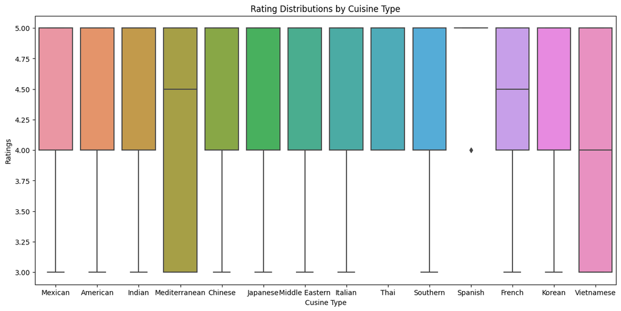

```python
#plotting ratings by cuisine type
plt.figure(figsize=(15,7))
sns.boxplot(data=df_rated, x='cuisine_type', y='rating_num')
plt.xlabel('Cusine Type')
plt.ylabel('Ratings')
plt.title('Rating Distributions by Cuisine Type');
```

```python
#finding number of ratings given per each cuisine type (not including 'Not given')
df_rated['cuisine_type'].value_counts()
```

```
American          368
Japanese          273
Italian           172
Chinese           133
Indian             50
Mexican            48
Middle Eastern     34
Mediterranean      32
Southern           13
French             10
Thai                9
Korean              9
Spanish             6
Vietnamese          5
Name: cuisine_type, dtype: int64
```

#### Observations:

Ratings across cuisine type appear to be relatively consistent.

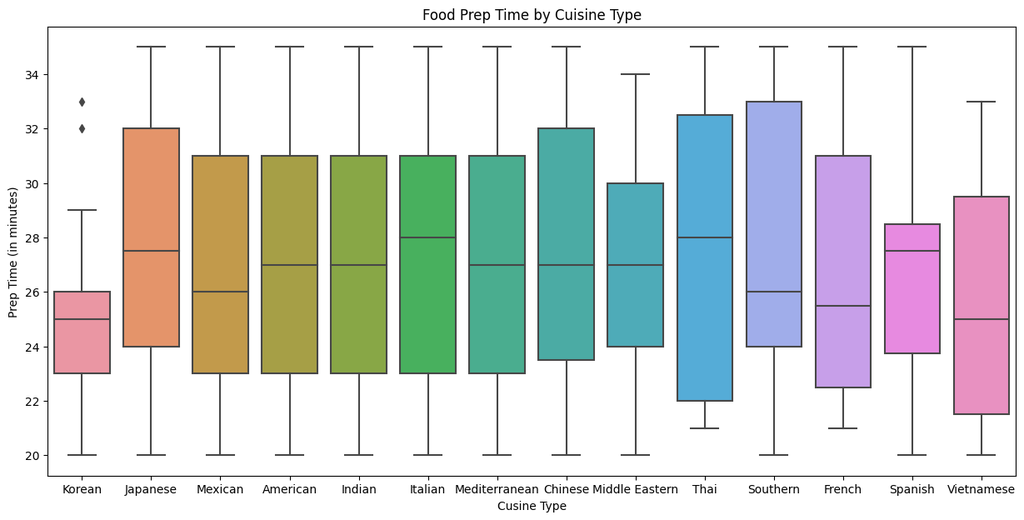

```python
#plotting food prep time by cuisine
plt.figure(figsize=(15,7))
sns.boxplot(data=df, x='cuisine_type', y='food_preparation_time')
plt.xlabel('Cusine Type')
plt.ylabel('Prep Time (in minutes)')
plt.title('Food Prep Time by Cuisine Type');
```

### Cost of Order compared between Cuisine Type

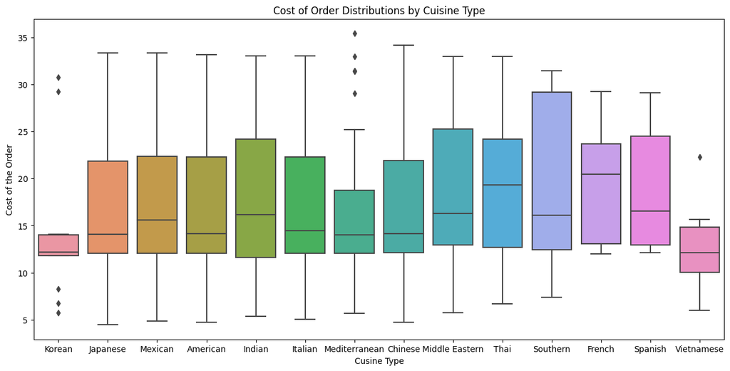

```python
# visualizing cost of order compared by cuisine type
plt.figure(figsize=(15,7))
sns.boxplot(data=df, x='cuisine_type', y='cost_of_the_order')
plt.xlabel('Cusine Type')
plt.ylabel('Cost of the Order')
plt.title('Cost of Order Distributions by Cuisine Type');
```

### Delivery time vs Day of Week

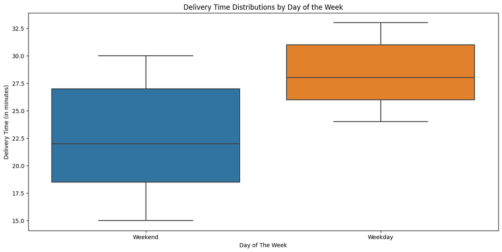

```python
#plotting delivery time by day of the week
plt.figure(figsize=(15,7))
sns.boxplot(data=df, x='day_of_the_week', y='delivery_time')
plt.xlabel('Day of The Week')
plt.ylabel('Delivery Time (in minutes)')
plt.title('Delivery Time Distributions by Day of the Week');
```

#### Observations:

Perhaps surprisingly, delivery times were overall faster on the weekends vs. weekdays.

### Rating vs. Cost of Order

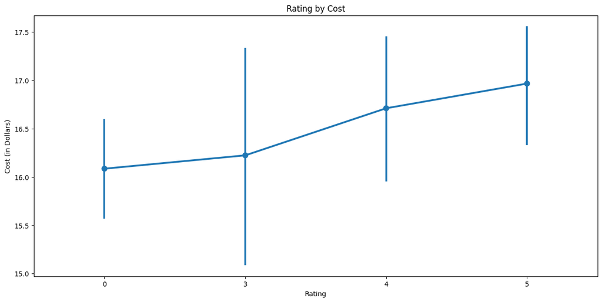

```python
#plotting rating by cost of order
plt.figure(figsize=(15,7))
sns.pointplot(data=df, x='rating_num', y='cost_of_the_order')
plt.title('Rating by Cost')
plt.xlabel('Rating')
plt.ylabel('Cost (in Dollars)');
```

#### Observations:

As the cost of the order increases, the overall rating increases as well. This might suggest that more expensive orders are higher quality foods, and therefore receive higher ratings.

### Rating vs. Delivery Time

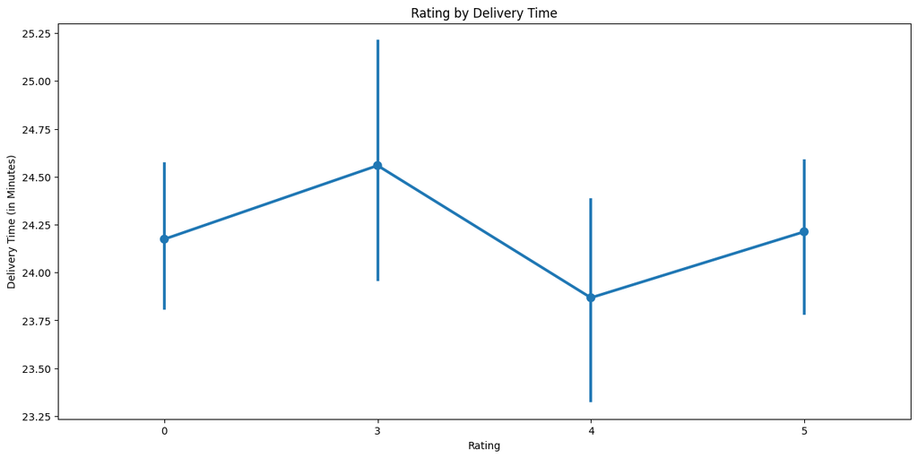

```python
# plotting rating by delivery time
plt.figure(figsize=(15,7))
sns.pointplot(data=df, x='rating_num', y='delivery_time')
plt.title('Rating by Delivery Time')
plt.xlabel('Rating')
plt.ylabel('Delivery Time (in Minutes)');
```

#### Observations:

There does not seem to be much relationship between delivery time and rating. While 4 star reviews had the fastest delivery times on average, and 3 star reviews had longer times, 5 star reviews were somwhere in the middle. Additionally, those who gave no review experienced similar delivery times to 5 star reviews.

#### Rating vs. Food Prep Time

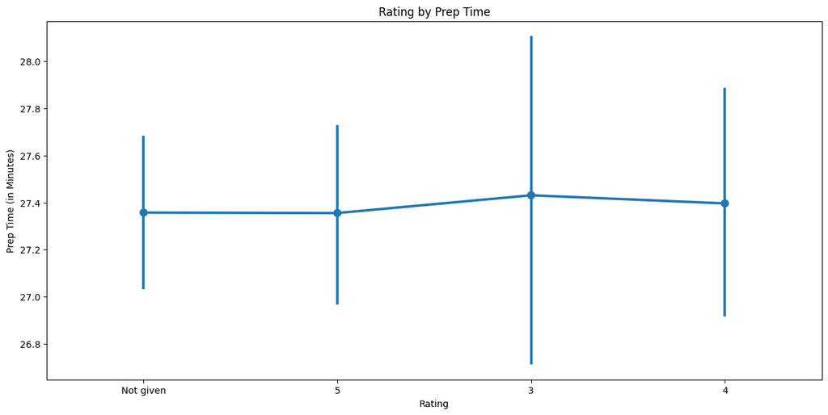

```python
# plotting rating by food prep time
plt.figure(figsize=(15,7))
sns.pointplot(data=df, x='rating', y='food_preparation_time')
plt.title('Rating by Prep Time')
plt.xlabel('Rating')
plt.ylabel('Prep Time (in Minutes)');
```

#### Observations:

Similar relationships from delivery time seem to be present, however the variation of the mean across categories is tighter.

### **Question 13:** The company wants to provide a promotional offer in the advertisement of the restaurants. The condition to get the offer is that the restaurants must have a rating count of more than 50 and the average rating should be greater than 4. Find the restaurants fulfilling the criteria to get the promotional offer

```python
# create a copy df of just rated restaurants
df_rated = df[df['rating'] != 'Not given'].copy()

#convert ratings column to numeric
df_rated['rating'] = pd.to_numeric(df_rated['rating'])

# create df containing rating counts per restaurant
df_rating_count = df_rated.groupby(['restaurant_name'])['rating'].count().sort_values(ascending=False).reset_index()
df_rating_count.head()
```

|  | restaurant_name | rating |
| --- | --- | --- |
| 0 | Shake Shack | 133 |
| 1 | The Meatball Shop | 84 |
| 2 | Blue Ribbon Sushi | 73 |
| 3 | Blue Ribbon Fried Chicken | 64 |
| 4 | RedFarm Broadway | 41 |

```python
# extract a list of restaurant names that have more than 50 ratings
rest_list = df_rating_count[df_rating_count['rating'] > 50]['restaurant_name'].tolist()
rest_list
```

```
['Shake Shack',
 'The Meatball Shop',
 'Blue Ribbon Sushi',
 'Blue Ribbon Fried Chicken']
```

```python
# verify for each restaurant name if their avg rating is greater than 4
df_50_ratings = df_rated[df_rated['restaurant_name'].isin(rest_list)].copy()

df_50_ratings.groupby(['restaurant_name'])['rating'].mean().dropna()
```

```
restaurant_name
Blue Ribbon Fried Chicken    4.328125
Blue Ribbon Sushi            4.219178
Shake Shack                  4.278195
The Meatball Shop            4.511905
Name: rating, dtype: float64
```

#### Observations:

Based on the above calculations, Blue Ribbon Fried Chicken, Blue Ribbon Sushi, Shake Shack and The Meatball Shop all meat the criteria for the promotional offer.

#### Observations:

### **Question 14:** The company charges the restaurant 25% on the orders having cost greater than 20 dollars and 15% on the orders having cost greater than 5 dollars. Find the net revenue generated by the company across all orders

```python
# create function to calculate revenue of each order
def calc_revenue(x):
  if x > 20:
    return x*.25
  elif x > 5:
    return x*.15
  else:
    return x*0

df['Revenue'] = df['cost_of_the_order'].apply(calc_revenue)
df.head()
```

|  | order_id | customer_id | restaurant_name | cuisine_type | cost_of_the_order | day_of_the_week | rating | food_preparation_time | delivery_time | rating_num | Revenue |
| --- | --- | --- | --- | --- | --- | --- | --- | --- | --- | --- | --- |
| 0 | 1477147 | 337525 | Hangawi | Korean | 30.75 | Weekend | Not given | 25 | 20 | 0 | 7.6875 |
| 1 | 1477685 | 358141 | Blue Ribbon Sushi Izakaya | Japanese | 12.08 | Weekend | Not given | 25 | 23 | 0 | 1.8120 |
| 2 | 1477070 | 66393 | Cafe Habana | Mexican | 12.23 | Weekday | 5 | 23 | 28 | 5 | 1.8345 |
| 3 | 1477334 | 106968 | Blue Ribbon Fried Chicken | American | 29.20 | Weekend | 3 | 25 | 15 | 3 | 7.3000 |
| 4 | 1478249 | 76942 | Dirty Bird to Go | American | 11.59 | Weekday | 4 | 25 | 24 | 4 | 1.7385 |

```python
# calculate total revenue based on revenue column and print
total_revenue = df['Revenue'].sum()
print('The total revenue of the company is: $', round(total_revenue, 2),".", sep='')
```

```
The total revenue of the company is: $6166.3.
```

#### Observations:

### **Question 15:** The company wants to analyze the total time required to deliver the food. What percentage of orders take more than 60 minutes to get delivered from the time the order is placed? (The food has to be prepared and then delivered)

```python
# create new column order_time calculated from food prep and delivery time
df['order_time'] = df['food_preparation_time'] + df['delivery_time']
df.head()
```

|  | order_id | customer_id | restaurant_name | cuisine_type | cost_of_the_order | day_of_the_week | rating | food_preparation_time | delivery_time | rating_num | Revenue | order_time |
| --- | --- | --- | --- | --- | --- | --- | --- | --- | --- | --- | --- | --- |
| 0 | 1477147 | 337525 | Hangawi | Korean | 30.75 | Weekend | Not given | 25 | 20 | 0 | 7.6875 | 45 |
| 1 | 1477685 | 358141 | Blue Ribbon Sushi Izakaya | Japanese | 12.08 | Weekend | Not given | 25 | 23 | 0 | 1.8120 | 48 |
| 2 | 1477070 | 66393 | Cafe Habana | Mexican | 12.23 | Weekday | 5 | 23 | 28 | 5 | 1.8345 | 51 |
| 3 | 1477334 | 106968 | Blue Ribbon Fried Chicken | American | 29.20 | Weekend | 3 | 25 | 15 | 3 | 7.3000 | 40 |
| 4 | 1478249 | 76942 | Dirty Bird to Go | American | 11.59 | Weekday | 4 | 25 | 24 | 4 | 1.7385 | 49 |

```python
# find number of orders with total order time greater than 60 min
over_60 = len(df[df['order_time'] > 60])

# calculate the percentage of orders over 60 minutes
perc_over_60 = round(((over_60 / len(df))*100) , 2)

print('The percentage of orders that take longer than 60 minutes is: ', perc_over_60, '%.', sep='')
```

```
The percentage of orders that take longer than 60 minutes is: 10.54%.
```

#### Observations:

The percentage of orders that takes longer than 60 minutes if 10.54%.

### **Question 16:** The company wants to analyze the delivery time of the orders on weekdays and weekends. How does the mean delivery time vary during weekdays and weekends?

```python
# find the mean delivery time grouped by day of week and find the difference
delivery_means = df.groupby(df['day_of_the_week']).delivery_time.mean().round(2)
dev_mean_diff = round(delivery_means[0] - delivery_means[1], 2)

# print the two averages and the difference between them
print('The average delivery time on weekdays is: ', delivery_means[0], ' minutes.\n'
      'The average delivery time on weekends is: ', delivery_means[1], ' minutes.\n'
      'The difference between the averages is: ', dev_mean_diff, ' minutes.', sep='')
```

```
The average delivery time on weekdays is: 28.34 minutes.
The average delivery time on weekends is: 22.47 minutes.
The difference between the averages is: 5.87 minutes.
```

#### Observations:

The average delivery time on weekdays is: 28.34 minutes. The average delivery time on weekends is: 22.47 minutes. The difference between the averages is: 5.87 minutes.